# Storm NOAA Data Shows Tornadoes Cause Most Harm and Damages

Jackie Milhans

July 25, 2015

## Synopsis

This project involves exploring the U.S. National Oceanic and Atmospheric Administration’s (NOAA) storm database. This database tracks characteristics of major storms and weather events in the United States, including when and where they occur, as well as estimates of any fatalities, injuries, and property damage.

The data shows that tornadoes cause the largest number of fatalities and injuries to humans. In addition, tornadoes cause the most economic damage when looking at combied property damage and crop damage. Tornadoes cause the largest property damages, while hail causes the greatest amount of crop damage.

## Data Processing

The data for this assignment come in the form of a comma-separated-value file compressed via the bzip2 algorithm to reduce its size. Here, we load the data.

```r
#download the data
fileURL <- "https://d396qusza40orc.cloudfront.net/repdata%2Fdata%2FStormData.csv.bz2"
download.file(fileURL, destfile = "repStormData.csv.bz2", method = "curl")

#read the csv file
noaaData <- read.csv("./repStormData.csv.bz2")
head(noaaData)
```

```
##   STATE__           BGN_DATE BGN_TIME TIME_ZONE COUNTY COUNTYNAME STATE
## 1       1  4/18/1950 0:00:00     0130       CST     97     MOBILE    AL
## 2       1  4/18/1950 0:00:00     0145       CST      3    BALDWIN    AL
## 3       1  2/20/1951 0:00:00     1600       CST     57    FAYETTE    AL
## 4       1   6/8/1951 0:00:00     0900       CST     89    MADISON    AL
## 5       1 11/15/1951 0:00:00     1500       CST     43    CULLMAN    AL
## 6       1 11/15/1951 0:00:00     2000       CST     77 LAUDERDALE    AL
##    EVTYPE BGN_RANGE BGN_AZI BGN_LOCATI END_DATE END_TIME COUNTY_END
## 1 TORNADO         0                                               0
## 2 TORNADO         0                                               0
## 3 TORNADO         0                                               0
## 4 TORNADO         0                                               0
## 5 TORNADO         0                                               0
## 6 TORNADO         0                                               0
##   COUNTYENDN END_RANGE END_AZI END_LOCATI LENGTH WIDTH F MAG FATALITIES
```

[output cut: 20 more lines]

```r
#load necessary libraries
library(Hmisc)
```

```r
library(ggplot2)
library(reshape)
library(car)
```

In order to better understand the number of injuries and fatalities by event to humans, we need to reformat the data. Here we examine the injuries to humans for events that occur.

```r
#clean data labels by changing to lower case
noaaData$EVTYPE <- capitalize(tolower(noaaData$EVTYPE))

#split and summarize data to better understand number of injuries and fatalities

harmful <- aggregate(cbind(FATALITIES, INJURIES) ~ EVTYPE, noaaData, sum)
harmData <- melt(head(harmful[order(-harmful$FATALITIES, -harmful$INJURIES),],10))
```

Now, we look at the economic impact of weather events by examining the property and crop damages caused by weather-related events.

According to the data description, estimates should be rounded to three significant digits, followed by an alphabetical character signifying the magnitude of the number, i.e., 1.55B for $1,550,000,000. Alphabetical characters used to signify magnitude include “K” for thousands, “M” for millions, and “B” for billions.

```r
#CROPDMG value will be changed accordingly to numeric using:
# "M", "K", "B" which mean 1000000, 1000, 1000000000 respectively.

noaaData$PROPDMGEXP <- as.numeric(recode(noaaData$PROPDMGEXP,"'0'=1;'1'=10;'2'=10^2;'3'=10^3;'4'=10^4;'5'=10^5;'6'=10^6;'7'=10^7;'8'=10^8;'b'=10^9;'h'=10^2;'k'=10^3;'m'=10^6;'-'=0;'?'=0;'+'=0"))

noaaData$CROPDMGEXP <- as.numeric(recode(noaaData$CROPDMGEXP,"'0'=1;'1'=10;'2'=10^2;'3'=10^3;'4'=10^4;'5'=10^5;'6'=10^6;'7'=10^7;'8'=10^8;'b'=10^9;'h'=10^2;'k'=10^3;'m'=10^6;'-'=0;'?'=0;'+'=0"))

#Get dollar amount by multiplying by exponential
noaaData$PROPDMGDOLL <- noaaData$PROPDMG * noaaData$PROPDMGEXP
noaaData$CROPDMGDOLL <- noaaData$CROPDMG * noaaData$CROPDMGEXP

#Reorganize the data by event type
econ <- aggregate(cbind(PROPDMGDOLL, CROPDMGDOLL) ~ EVTYPE, noaaData, sum)
econData <- melt(head(econ[order(-econ$PROPDMGDOLL, -econ$CROPDMGDOLL),],10))
```

## Results

### Human Health Impact

Across the United States, the types of events that are most harmful with respect to population health can be seen as follows. We can see in the plot, the number of fatalities and injuries by weather-related event type.

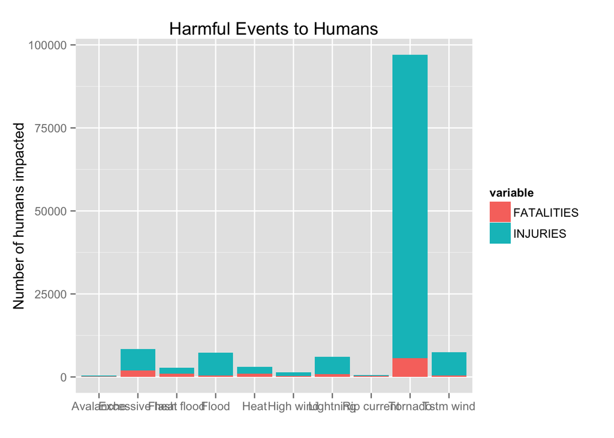

```r
ggplot(harmData, aes(x = EVTYPE, y = value, fill = variable)) +
        geom_bar(stat = "identity") + ggtitle("Harmful Events to Humans") +
        labs(x = "", y = "Number of humans impacted")
```

Figure 1: Injuries and fatalities to humans by weather-related event.

We can see that tornadoes have the highest number of injuries and fatalities by far. In addition, we can see that weather-related events cause less deaths than fatalities.

### Economic Damage Impact

Now, we analyze across the United States, which types of events have the greatest economic consequences.

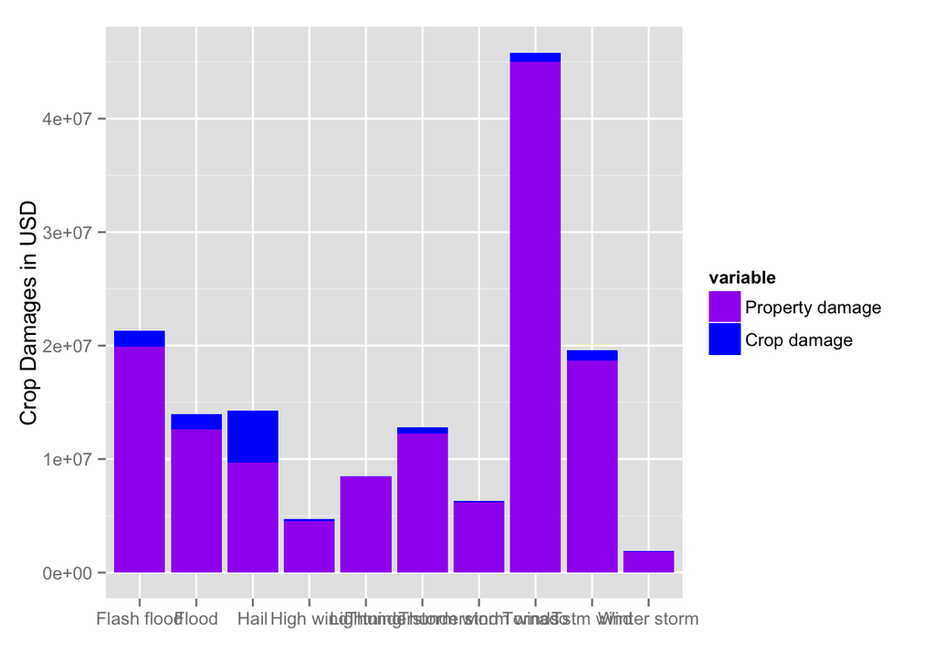

```r
ggplot(econData, aes(x=EVTYPE, y=value, fill=variable)) +
        geom_bar(stat = "identity") + labs(x="", y = "Crop Damages in USD") +
        scale_fill_manual(values = c("purple", "blue"), labels = c("Property damage", "Crop damage"))
```

From the plot, we can see that there are significant damages from tornadoes again for economic damages. When only looking at crop damages, we see that hail causes the most damage.